# Final Project LOL

Due: Wednesday 12/19 at 11:59am, Canvas submission

## The Data

The dataset I have chosen to conduct my regression analysis is the [(LoL) League of Legends Ranked Games dataset](https://www.kaggle.com/datasets/datasnaek/league-of-legends/?select=games.csv). This data looks at ranked League of Legends games played during season 9 in the EUW region. This dataset was collected using the Riot Games API, which makes it easy to look up and collect information on a users ranked history and collect their games.

```r
# Load packages
library(ggplot2)
library(rstanarm)
library(bayesplot)
library(bayesrules)
library(tidyverse)
library(tidybayes)
library(dplyr)
library(broom.mixed)
library(interactions)
```

To preface this analysis, one must first understand the game of League of Legends, or LOL for short. In LOL, two 5 person teams fight to destroy each others nexus and get to choose and ban a champion, each with a different set of skills and abilities, and 2 summoner spells to do so. Along the way, the players must both fight each other, destroy objectives such as towers and inhibitors, and strategize effectively to reach the opponent’s nexus. There are also several monsters that teams can defeat to buff them as well, such as Rift Herald, Baron Nashor, and an assorted set of Dragons.

We will use `lol_data` to build various models of League of Legends `gameDuration`. Throughout, we’ll utilize weakly informative priors and a basic understanding that LOL games usually are [30 minutes](https://www.leagueofgraphs.com/stats/game-durations) but can range from 25-35 minutes. We will asses an array of different predictors and combinations to determine what can provide us the best fit for predicting the game duration of a League of Legends game. A base criteria for these games is there at least needs to be one tower, one inhibitor, and one champion kill for each game. This is to mitigate the amount of games that teams may have forfeited due to a player leaving or trolling.

```r
lol_data <- read.csv("games.csv",
                    sep=",",
                    na.strings=c(""," ","NA","N/A")
)
head(lol_data)
```

|  | gameId | creationTime | gameDuration | seasonId | winner | firstBlood | firstTower | firstInhibitor | firstBaron | firstDragon | firstRiftHerald | t1_champ1id | t1_champ1_sum1 | t1_champ1_sum2 | t1_champ2id | t1_champ2_sum1 | t1_champ2_sum2 | t1_champ3id | t1_champ3_sum1 | t1_champ3_sum2 | t1_champ4id | t1_champ4_sum1 | t1_champ4_sum2 | t1_champ5id | t1_champ5_sum1 | t1_champ5_sum2 | t1_towerKills | t1_inhibitorKills | t1_baronKills | … |
| --- | --- | --- | --- | --- | --- | --- | --- | --- | --- | --- | --- | --- | --- | --- | --- | --- | --- | --- | --- | --- | --- | --- | --- | --- | --- | --- | --- | --- | --- | --- |
| 1 | 3326086514 | 1.504279e+12 | 1949 | 9 | 1 | 2 | 1 | 1 | 1 | 1 | 2 | 8 | 12 | 4 | 432 | 3 | 4 | 96 | 4 | 7 | 11 | 11 | 6 | 112 | 4 | 14 | 11 | 1 | 2 | … |
| 2 | 3229566029 | 1.497849e+12 | 1851 | 9 | 1 | 1 | 1 | 1 | 0 | 1 | 1 | 119 | 7 | 4 | 39 | 12 | 4 | 76 | 4 | 3 | 10 | 4 | 14 | 35 | 4 | 11 | 10 | 4 | 0 | … |
| 3 | 3327363504 | 1.504360e+12 | 1493 | 9 | 1 | 2 | 1 | 1 | 1 | 2 | 0 | 18 | 4 | 7 | 141 | 11 | 4 | 267 | 3 | 4 | 68 | 4 | 12 | 38 | 12 | 4 | 8 | 1 | 1 | … |
| 4 | 3326856598 | 1.504349e+12 | 1758 | 9 | 1 | 1 | 1 | 1 | 1 | 1 | 0 | 57 | 4 | 12 | 63 | 4 | 14 | 29 | 4 | 7 | 61 | 4 | 1 | 36 | 11 | 4 | 9 | 2 | 1 | … |
| 5 | 3330080762 | 1.504554e+12 | 2094 | 9 | 1 | 2 | 1 | 1 | 1 | 1 | 0 | 19 | 4 | 12 | 29 | 11 | 4 | 40 | 4 | 3 | 119 | 4 | 7 | 134 | 7 | 4 | 9 | 2 | 1 | … |
| 6 | 3287435705 | 1.501668e+12 | 2059 | 9 | 1 | 2 | 2 | 1 | 1 | 2 | 0 | 40 | 3 | 4 | 141 | 11 | 4 | 24 | 12 | 4 | 45 | 3 | 4 | 67 | 4 | 7 | 8 | 1 | 1 | … |

## Setting Up the Data

Transforming data to fit baseline of at least one kill, tower, and inhibitor

```r
lol_data <- lol_data[!(lol_data$firstBlood == 0 | lol_data$firstTower == 0 | lol_data$firstInhibitor == 0), ]
```

```r
nrow(lol_data)
```

```
[1] 45214
```

```r
colnames(lol_data)
```

```
 [1] "gameId"             "creationTime"       "gameDuration"
 [4] "seasonId"           "winner"             "firstBlood"
 [7] "firstTower"         "firstInhibitor"     "firstBaron"
[10] "firstDragon"        "firstRiftHerald"    "t1_champ1id"
[13] "t1_champ1_sum1"     "t1_champ1_sum2"     "t1_champ2id"
[16] "t1_champ2_sum1"     "t1_champ2_sum2"     "t1_champ3id"
[19] "t1_champ3_sum1"     "t1_champ3_sum2"     "t1_champ4id"
[22] "t1_champ4_sum1"     "t1_champ4_sum2"     "t1_champ5id"
[25] "t1_champ5_sum1"     "t1_champ5_sum2"     "t1_towerKills"
[28] "t1_inhibitorKills"  "t1_baronKills"      "t1_dragonKills"
[31] "t1_riftHeraldKills" "t1_ban1"            "t1_ban2"
[34] "t1_ban3"            "t1_ban4"            "t1_ban5"
[37] "t2_champ1id"        "t2_champ1_sum1"     "t2_champ1_sum2"
[40] "t2_champ2id"        "t2_champ2_sum1"     "t2_champ2_sum2"
[43] "t2_champ3id"        "t2_champ3_sum1"     "t2_champ3_sum2"
[46] "t2_champ4id"        "t2_champ4_sum1"     "t2_champ4_sum2"
[49] "t2_champ5id"        "t2_champ5_sum1"     "t2_champ5_sum2"
[52] "t2_towerKills"      "t2_inhibitorKills"  "t2_baronKills"
[55] "t2_dragonKills"     "t2_riftHeraldKills" "t2_ban1"
[58] "t2_ban2"            "t2_ban3"            "t2_ban4"
[61] "t2_ban5"
```

We can clean up our data by omitting unnecessary columns

```r
lol_data <- subset(lol_data, select = -c(t2_ban1, t2_ban2, t2_ban3, t2_ban4, t2_ban5, t1_ban1, t1_ban2, t1_ban3, t1_ban4, t1_ban5, t1_champ1_sum1, t1_champ2_sum1, t1_champ3_sum1, t1_champ4_sum1, t1_champ5_sum1, t2_champ5_sum1, t2_champ1_sum1, t2_champ2_sum1, t2_champ3_sum1, t2_champ4_sum1, t2_champ5_sum1, t1_champ1_sum2, t1_champ2_sum2, t1_champ3_sum2, t1_champ4_sum2, t1_champ5_sum2, t2_champ1_sum2, t2_champ1_sum2, t2_champ2_sum2, t2_champ3_sum2, t2_champ4_sum2, t2_champ5_sum2, t1_champ1id, t1_champ2id, t1_champ3id, t1_champ4id, t1_champ5id, t2_champ1id, t2_champ2id, t2_champ3id, t2_champ4id, t2_champ5id))

colnames(lol_data)
```

```
 [1] "gameId"             "creationTime"       "gameDuration"
 [4] "seasonId"           "winner"             "firstBlood"
 [7] "firstTower"         "firstInhibitor"     "firstBaron"
[10] "firstDragon"        "firstRiftHerald"    "t1_towerKills"
[13] "t1_inhibitorKills"  "t1_baronKills"      "t1_dragonKills"
[16] "t1_riftHeraldKills" "t2_towerKills"      "t2_inhibitorKills"
[19] "t2_baronKills"      "t2_dragonKills"     "t2_riftHeraldKills"
```

We can also covert some of the columns to factors for team 1 and team 2 for ease of visualization and interpretation

```r
lol_data$winner <- as.factor(lol_data$winner)
lol_data$firstBlood <- as.factor(lol_data$firstBlood)
lol_data$firstTower <- as.factor(lol_data$firstTower)
lol_data$firstInhibitor <- as.factor(lol_data$firstInhibitor)
lol_data$firstBaron <- as.factor(lol_data$firstBaron)
lol_data$firstDragon <- as.factor(lol_data$firstDragon)
lol_data$firstRiftHerald <- as.factor(lol_data$firstRiftHerald)
```

```r
head(lol_data)
```

|  | gameId | creationTime | gameDuration | seasonId | winner | firstBlood | firstTower | firstInhibitor | firstBaron | firstDragon | firstRiftHerald | t1_towerKills | t1_inhibitorKills | t1_baronKills | t1_dragonKills | t1_riftHeraldKills | t2_towerKills | t2_inhibitorKills | t2_baronKills | t2_dragonKills | t2_riftHeraldKills |
| --- | --- | --- | --- | --- | --- | --- | --- | --- | --- | --- | --- | --- | --- | --- | --- | --- | --- | --- | --- | --- | --- |
| 1 | 3326086514 | 1.504279e+12 | 1949 | 9 | 1 | 2 | 1 | 1 | 1 | 1 | 2 | 11 | 1 | 2 | 3 | 0 | 5 | 0 | 0 | 1 | 1 |
| 2 | 3229566029 | 1.497849e+12 | 1851 | 9 | 1 | 1 | 1 | 1 | 0 | 1 | 1 | 10 | 4 | 0 | 2 | 1 | 2 | 0 | 0 | 0 | 0 |
| 3 | 3327363504 | 1.504360e+12 | 1493 | 9 | 1 | 2 | 1 | 1 | 1 | 2 | 0 | 8 | 1 | 1 | 1 | 0 | 2 | 0 | 0 | 1 | 0 |
| 4 | 3326856598 | 1.504349e+12 | 1758 | 9 | 1 | 1 | 1 | 1 | 1 | 1 | 0 | 9 | 2 | 1 | 2 | 0 | 0 | 0 | 0 | 0 | 0 |
| 5 | 3330080762 | 1.504554e+12 | 2094 | 9 | 1 | 2 | 1 | 1 | 1 | 1 | 0 | 9 | 2 | 1 | 3 | 0 | 3 | 0 | 0 | 1 | 0 |
| 6 | 3287435705 | 1.501668e+12 | 2059 | 9 | 1 | 2 | 2 | 1 | 1 | 2 | 0 | 8 | 1 | 1 | 1 | 0 | 6 | 0 | 0 | 3 | 0 |

## Summary Analysis

Here are some visualizations and statistics to help better understand our data and what we are working with.

```r
summary(lol_data)
```

```
     gameId           creationTime        gameDuration     seasonId
 Min.   :3.215e+09   Min.   :1.497e+12   Min.   : 477   Min.   :9
 1st Qu.:3.292e+09   1st Qu.:1.502e+12   1st Qu.:1632   1st Qu.:9
 Median :3.320e+09   Median :1.504e+12   Median :1895   Median :9
 Mean   :3.306e+09   Mean   :1.503e+12   Mean   :1930   Mean   :9
 3rd Qu.:3.327e+09   3rd Qu.:1.504e+12   3rd Qu.:2196   3rd Qu.:9
 Max.   :3.332e+09   Max.   :1.505e+12   Max.   :4728   Max.   :9
 winner    firstBlood firstTower firstInhibitor firstBaron firstDragon
 1:22867   1:23151    1:23248    1:23054        0:14617    0:  434
 2:22347   2:22063    2:21966    2:22160        1:14469    1:22258
                                                2:16128    2:22522



 firstRiftHerald t1_towerKills    t1_inhibitorKills t1_baronKills
 0:21922         Min.   : 0.000   Min.   : 0.000    Min.   :0.0000
 1:11933         1st Qu.: 3.000   1st Qu.: 0.000    1st Qu.:0.0000
 2:11359         Median : 7.000   Median : 1.000    Median :0.0000
                 Mean   : 6.173   Mean   : 1.159    Mean   :0.4173
                 3rd Qu.:10.000   3rd Qu.: 2.000    3rd Qu.:1.0000
                 Max.   :11.000   Max.   :10.000    Max.   :5.0000
 t1_dragonKills  t1_riftHeraldKills t2_towerKills    t2_inhibitorKills
 Min.   :0.000   Min.   :0.0000     Min.   : 0.000   Min.   : 0.000
 1st Qu.:0.000   1st Qu.:0.0000     1st Qu.: 2.000   1st Qu.: 0.000
 Median :1.000   Median :0.0000     Median : 7.000   Median : 1.000
 Mean   :1.483   Mean   :0.2639     Mean   : 6.014   Mean   : 1.122
 3rd Qu.:2.000   3rd Qu.:1.0000     3rd Qu.:10.000   3rd Qu.: 2.000
 Max.   :6.000   Max.   :1.0000     Max.   :11.000   Max.   :10.000
 t2_baronKills    t2_dragonKills  t2_riftHeraldKills
 Min.   :0.0000   Min.   :0.000   Min.   :0.0000
 1st Qu.:0.0000   1st Qu.:0.000   1st Qu.:0.0000
 Median :0.0000   Median :1.000   Median :0.0000
 Mean   :0.4641   Mean   :1.506   Mean   :0.2512
 3rd Qu.:1.0000   3rd Qu.:2.000   3rd Qu.:1.0000
 Max.   :4.0000   Max.   :6.000   Max.   :1.0000
```

Some conclusions we can make here:

- The mean game time is around 1930 seconds (roughly 32 minutes)
- Game duration lies mostly between 1632 and 2196
- Team 1 has won more games, has more first bloods, towers, inhibitors, and rift heralds
- Team 2 has more first barons and dragons.
- Team 1’s tower, inhibitor, and herald kills are higher than Team 2’s which is reflected from them getting the first of each more often than not.
- Team 2’s dragon and baron kills are higher than Team 1’s which is reflected from them getting the first of each more often than not.

## Visualizations

We can use ggplot do visualize some of our findings

### Response Distribution

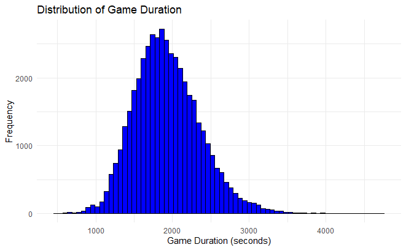

```r
ggplot(lol_data, aes(x = gameDuration)) +
  geom_histogram(binwidth = 60, fill = "blue", color = "black") +
  labs(x = "Game Duration (seconds)", y = "Frequency", title = "Distribution of Game Duration") +
  theme_minimal()
```

Game duration seems to be a bit right-skewed

### First Comparisons

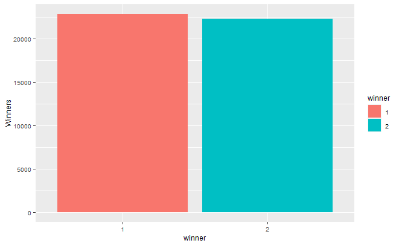

```r
ggplot(lol_data, aes(x = winner, fill = winner)) +
      geom_bar() +
      theme(text = element_text(size=9)) +
      labs(y = "Winners")
```

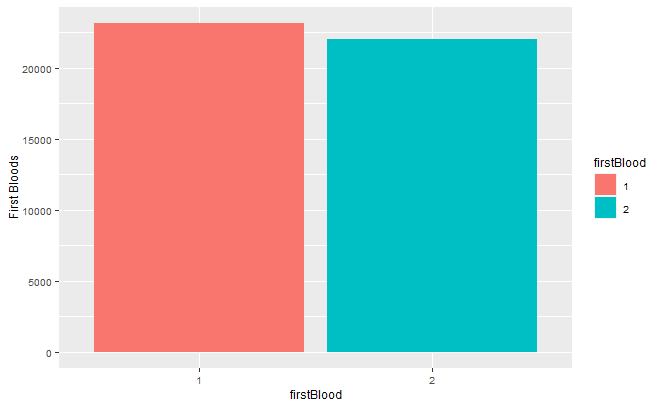

```r
ggplot(lol_data, aes(x = firstBlood, fill = firstBlood)) +
      geom_bar() +
      theme(text = element_text(size=9)) +
      labs(y = "First Bloods")
```

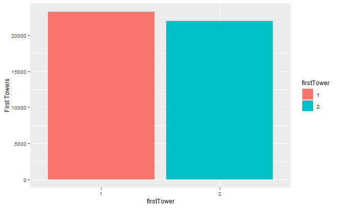

```r
ggplot(lol_data, aes(x = firstTower, fill = firstTower)) +
      geom_bar() +
      theme(text = element_text(size=9)) +
      labs(y = "First Towers")
```

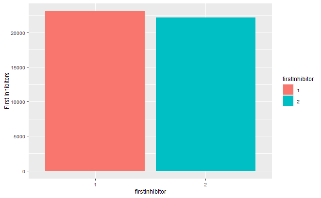

```r
ggplot(lol_data, aes(x = firstInhibitor, fill = firstInhibitor)) +
      geom_bar() +
      theme(text = element_text(size=9)) +
      labs(y = "First Inhibitors")
```

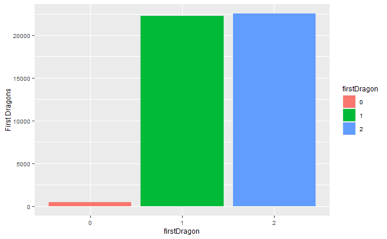

```r
ggplot(lol_data, aes(x = firstDragon, fill = firstDragon)) +
      geom_bar() +
      theme(text = element_text(size=9)) +
      labs(y = "First Dragons")
```

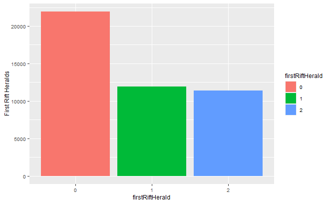

```r
ggplot(lol_data, aes(x = firstRiftHerald, fill = firstRiftHerald)) +
      geom_bar() +
      theme(text = element_text(size=9)) +
      labs(y = "First Rift Heralds")
```

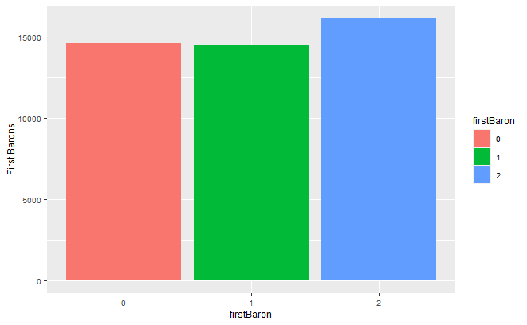

```r
ggplot(lol_data, aes(x = firstBaron, fill = firstBaron)) +
      geom_bar() +
      theme(text = element_text(size=9)) +
      labs(y = "First Barons")
```

These all are consistent with our previous summary findings about first categories

### Total Objectives Comparisons

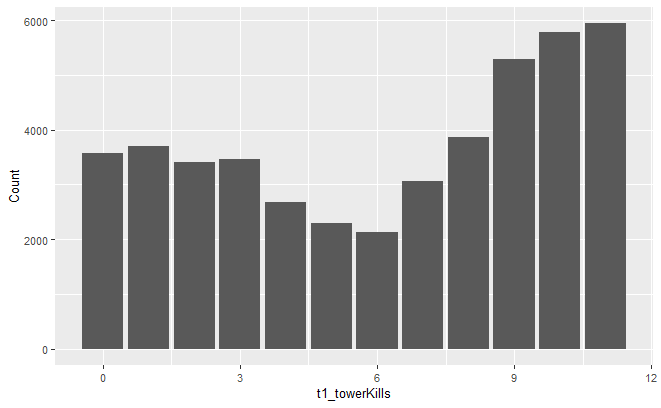

```r
ggplot(lol_data, aes(x = t1_towerKills)) +
      geom_bar() +
      theme(text = element_text(size=10)) +
      labs(y = "Count")
```

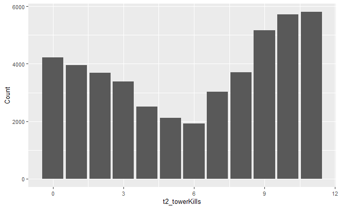

```r
ggplot(lol_data, aes(x = t2_towerKills)) +
      geom_bar() +
      theme(text = element_text(size=10)) +
      labs(y = "Count")
```

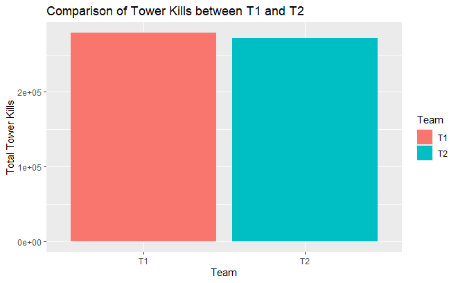

```r
tower_kills <- data.frame(Team = c("T1", "T2"),
                          Kills = c(sum(lol_data$t1_towerKills, na.rm = TRUE),
                                    sum(lol_data$t2_towerKills, na.rm = TRUE)))

ggplot(tower_kills, aes(x = Team, y = Kills, fill = Team)) +
  geom_bar(stat = "identity") +
  labs(x = "Team", y = "Total Tower Kills", title = "Comparison of Tower Kills between T1 and T2")
```

More often than not, both teams tend to kill >6 towers per game

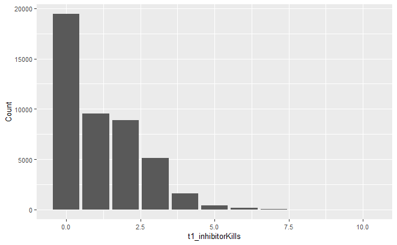

```r
ggplot(lol_data, aes(x = t1_inhibitorKills)) +
      geom_bar() +
      theme(text = element_text(size=10)) +
      labs(y = "Count")
```

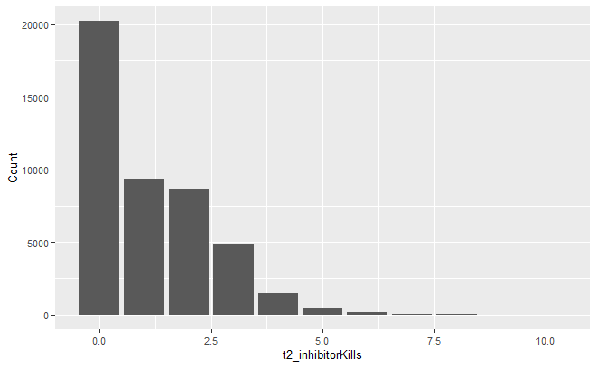

```r
ggplot(lol_data, aes(x = t2_inhibitorKills)) +
      geom_bar() +
      theme(text = element_text(size=10)) +
      labs(y = "Count")
```

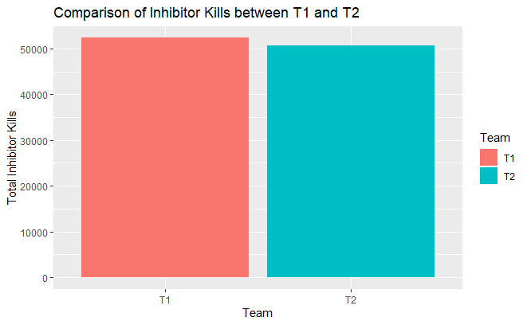

```r
# Calculate the total number of inhibitor kills for each team
inhibitor_kills <- data.frame(Team = c("T1", "T2"),
                              Kills = c(sum(lol_data$t1_inhibitorKills, na.rm = TRUE),
                                        sum(lol_data$t2_inhibitorKills, na.rm = TRUE)))

ggplot(inhibitor_kills, aes(x = Team, y = Kills, fill = Team)) +
  geom_bar(stat = "identity") +
  labs(x = "Team", y = "Total Inhibitor Kills", title = "Comparison of Inhibitor Kills between T1 and T2")
```

Games usually end with 0 to 2 inhibitors being destroyed, likely due to late game forfeits or steam rolls (which is often the case in many games)

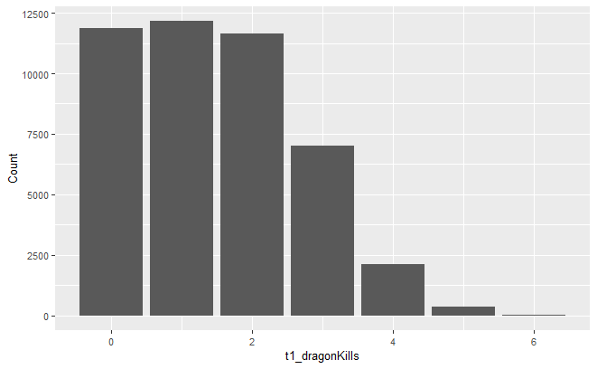

```r
ggplot(lol_data, aes(x = t1_dragonKills)) +
      geom_bar() +
      theme(text = element_text(size=10)) +
      labs(y = "Count")
```

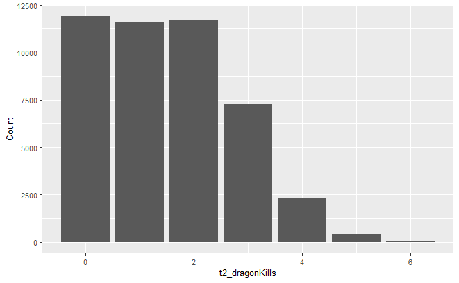

```r
ggplot(lol_data, aes(x = t2_dragonKills)) +
      geom_bar() +
      theme(text = element_text(size=10)) +
      labs(y = "Count")
```

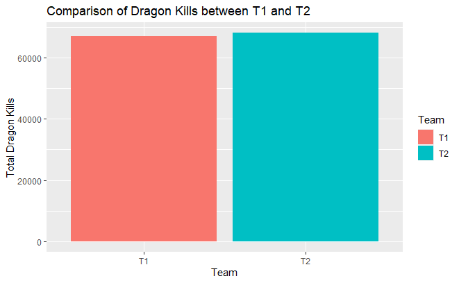

```r
# Calculate the total number of dragon kills for each team
dragon_kills <- data.frame(Team = c("T1", "T2"),
                           Kills = c(sum(lol_data$t1_dragonKills, na.rm = TRUE),
                                     sum(lol_data$t2_dragonKills, na.rm = TRUE)))

ggplot(dragon_kills, aes(x = Team, y = Kills, fill = Team)) +
  geom_bar(stat = "identity") +
  labs(x = "Team", y = "Total Dragon Kills", title = "Comparison of Dragon Kills between T1 and T2")
```

Dragon kills comfortably lie within the 0-2 range

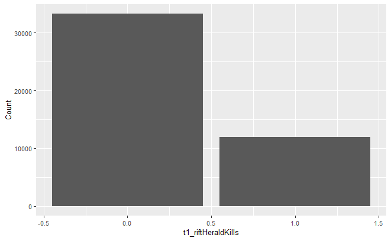

```r
ggplot(lol_data, aes(x = t1_riftHeraldKills)) +
      geom_bar() +
      theme(text = element_text(size=10)) +
      labs(y = "Count")
```

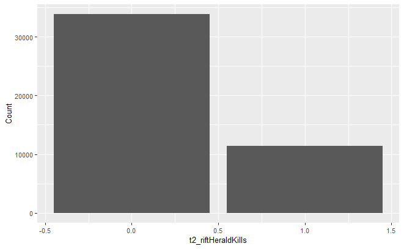

```r
ggplot(lol_data, aes(x = t2_riftHeraldKills)) +
      geom_bar() +
      theme(text = element_text(size=10)) +
      labs(y = "Count")
```

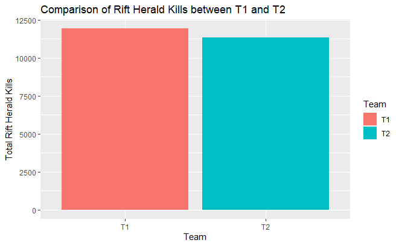

```r
# Calculate the total number of rift herald kills for each team
riftHerald_kills <- data.frame(Team = c("T1", "T2"),
                               Kills = c(sum(lol_data$t1_riftHeraldKills, na.rm = TRUE),
                                         sum(lol_data$t2_riftHeraldKills, na.rm = TRUE)))

ggplot(riftHerald_kills, aes(x = Team, y = Kills, fill = Team)) +
  geom_bar(stat = "identity") +
  labs(x = "Team", y = "Total Rift Herald Kills", title = "Comparison of Rift Herald Kills between T1 and T2")
```

Rift herald only spawns from 9:50 - 19:45 during the game and is most often only taken once if at all

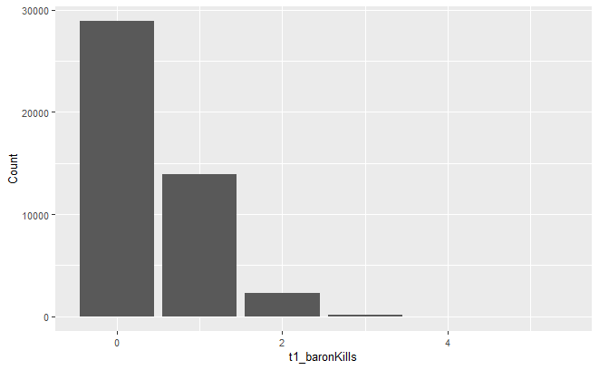

```r
ggplot(lol_data, aes(x = t1_baronKills)) +
      geom_bar() +
      theme(text = element_text(size=10)) +
      labs(y = "Count")
```

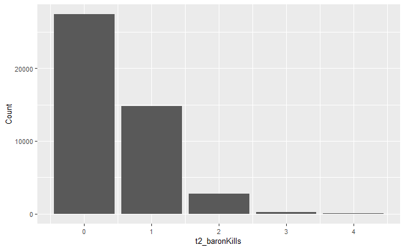

```r
ggplot(lol_data, aes(x = t2_baronKills)) +
      geom_bar() +
      theme(text = element_text(size=10)) +
      labs(y = "Count")
```

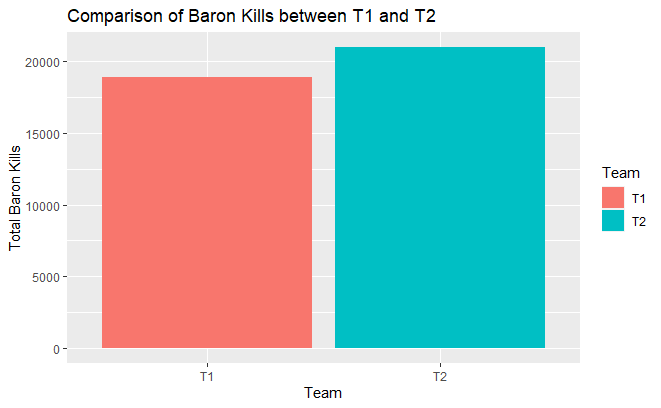

```r
# Calculate the total number of baron kills for each team
baron_kills <- data.frame(Team = c("T1", "T2"),
                          Kills = c(sum(lol_data$t1_baronKills, na.rm = TRUE),
                                    sum(lol_data$t2_baronKills, na.rm = TRUE)))

ggplot(baron_kills, aes(x = Team, y = Kills, fill = Team)) +
  geom_bar(stat = "identity") +
  labs(x = "Team", y = "Total Baron Kills", title = "Comparison of Baron Kills between T1 and T2")
```

Baron spawns after the rift herald and usually is game over if taken and used properly, hence why the amount taken is usually 0 or 1 as sometimes games end before it can be taken

## Base Model and Prior Modeling

Lets start off with a base model to see if we can get insight from just the winner of the match

```r
base <- stan_glm(gameDuration ~ winner,
  data = lol_data, family = gaussian,
  prior_intercept = normal(1800, 150, autoscale = TRUE),
  prior = normal(0, 2.5, autoscale = TRUE),
  prior_aux = exponential(1, autoscale = TRUE),
  chains = 4, iter = 5000*2, seed = 84735)
```

```r
prior_summary(base)
```

```
Priors for model 'base'
------
Intercept (after predictors centered)
  Specified prior:
    ~ normal(location = 1800, scale = 150)
  Adjusted prior:
    ~ normal(location = 1800, scale = 64093)

Coefficients
  Specified prior:
    ~ normal(location = 0, scale = 2.5)
  Adjusted prior:
    ~ normal(location = 0, scale = 2137)

Auxiliary (sigma)
  Specified prior:
    ~ exponential(rate = 1)
  Adjusted prior:
    ~ exponential(rate = 0.0023)
------
See help('prior_summary.stanreg') for more details
```

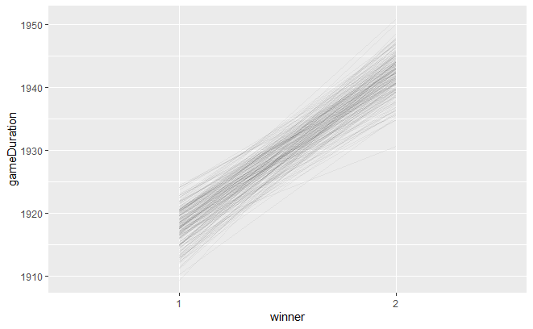

```r
base_priors <- update(base, prior_PD = TRUE)
# 200 prior model lines
lol_data %>%
  add_fitted_draws(base, n = 200) %>%
  ggplot(aes(x = winner, y = gameDuration)) +
    geom_line(aes(y = .value, group = .draw), alpha = 0.05)
```

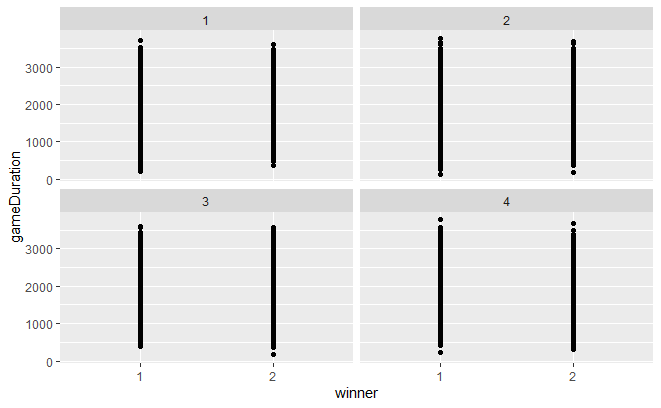

```r
# 4 prior simulated datasets
set.seed(3)
lol_data %>%
  add_predicted_draws(base, n = 4) %>%
  ggplot(aes(x = winner, y = gameDuration)) +
    geom_point(aes(y = .prediction, group = .draw)) +
    facet_wrap(~ .draw)
```

Game duration lies between 500-3500 seconds which falls in line with our summary

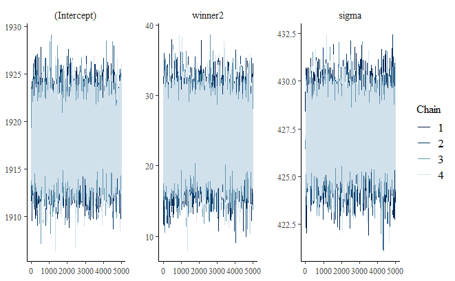

```r
mcmc_trace(base, size = .1)
```

Plots look fast mixing and consistent

```r
rhat(base)
```

```
(Intercept)     winner2       sigma
  0.9998587   0.9999295   0.9999225
```

Rhat close to 1 and not >1.05, good

```r
neff_ratio(base)
```

```
(Intercept)     winner2       sigma
    0.92220     0.95970     0.95575
```

neff ratio is a little high but still acceptable, >.10 which is good

```r
tidy(base, effects = c("fixed", "aux"),
     conf.int = TRUE, conf.level = 0.95)
```

| term | estimate | std.error | conf.low | conf.high |
| --- | --- | --- | --- | --- |
| (Intercept) | 1917.94817 | 2.857255 | 1912.4243 | 1923.59569 |
| winner2 | 23.90949 | 4.016213 | 16.0977 | 31.72662 |
| sigma | 427.12833 | 1.410343 | 424.3705 | 429.92975 |
| mean_PPD | 1929.76959 | 2.847234 | 1924.1961 | 1935.39231 |

Overall the model could work, but more investigation should be done to improve what we have

## Interaction Investigation

Lets see if there are some interactions we can expect

Speaking from experience in playing the game myself, I predict the dragon and baron kills will have a big impact on the game duration due to the buffs they give each member of the team being crucial to winning

```r
int <- stan_glm(gameDuration ~ t1_dragonKills:t2_dragonKills,
  data = lol_data, family = gaussian,
  prior_intercept = normal(1800, 150, autoscale = TRUE),
  prior = normal(0, 2.5, autoscale = TRUE),
  prior_aux = exponential(1, autoscale = TRUE),
  chains = 4, iter = 5000*2, seed = 84735)
```

```r
int2 <- stan_glm(gameDuration ~ t1_baronKills:t2_baronKills,
  data = lol_data, family = gaussian,
  prior_intercept = normal(1800, 150, autoscale = TRUE),
  prior = normal(0, 2.5, autoscale = TRUE),
  prior_aux = exponential(1, autoscale = TRUE),
  chains = 4, iter = 5000*2, seed = 84735)
```

```r
summary(int)
```

```
Model Info:
 function:     stan_glm
 family:       gaussian [identity]
 formula:      gameDuration ~ t1_dragonKills:t2_dragonKills
 algorithm:    sampling
 sample:       20000 (posterior sample size)
 priors:       see help('prior_summary')
 observations: 45214
 predictors:   2

Estimates:
                                mean   sd     10%    50%    90%
(Intercept)                   1728.5    2.0 1725.9 1728.5 1731.1
t1_dragonKills:t2_dragonKills  147.5    0.9  146.3  147.5  148.6
sigma                          340.5    1.1  339.0  340.5  341.9

Fit Diagnostics:
           mean   sd     10%    50%    90%
mean_PPD 1929.8    2.3 1926.9 1929.8 1932.7

The mean_ppd is the sample average posterior predictive distribution of the outcome variable (for details see help('summary.stanreg')).

MCMC diagnostics
                              mcse Rhat n_eff
(Intercept)                   0.0  1.0  18279
t1_dragonKills:t2_dragonKills 0.0  1.0  21144
sigma                         0.0  1.0  18662
mean_PPD                      0.0  1.0  18790
log-posterior                 0.0  1.0   9402

For each parameter, mcse is Monte Carlo standard error, n_eff is a crude measure of effective sample size, and Rhat is the potential scale reduction factor on split chains (at convergence Rhat=1).
```

```r
summary(int2)
```

```
Model Info:
 function:     stan_glm
 family:       gaussian [identity]
 formula:      gameDuration ~ t1_baronKills:t2_baronKills
 algorithm:    sampling
 sample:       20000 (posterior sample size)
 priors:       see help('prior_summary')
 observations: 45214
 predictors:   2

Estimates:
                              mean   sd     10%    50%    90%
(Intercept)                 1884.0    1.9 1881.6 1884.0 1886.4
t1_baronKills:t2_baronKills  466.7    4.8  460.4  466.6  472.8
sigma                        390.0    1.3  388.4  390.0  391.7

Fit Diagnostics:
           mean   sd     10%    50%    90%
mean_PPD 1929.8    2.6 1926.5 1929.8 1933.1

The mean_ppd is the sample average posterior predictive distribution of the outcome variable (for details see help('summary.stanreg')).

MCMC diagnostics
                            mcse Rhat n_eff
(Intercept)                 0.0  1.0  17022
t1_baronKills:t2_baronKills 0.0  1.0  20014
sigma                       0.0  1.0  18691
mean_PPD                    0.0  1.0  18228
log-posterior               0.0  1.0   9914

For each parameter, mcse is Monte Carlo standard error, n_eff is a crude measure of effective sample size, and Rhat is the potential scale reduction factor on split chains (at convergence Rhat=1).
```

Summary stats look promising with both values not containing 0 for their 95% CI showing they are significant and can be useful

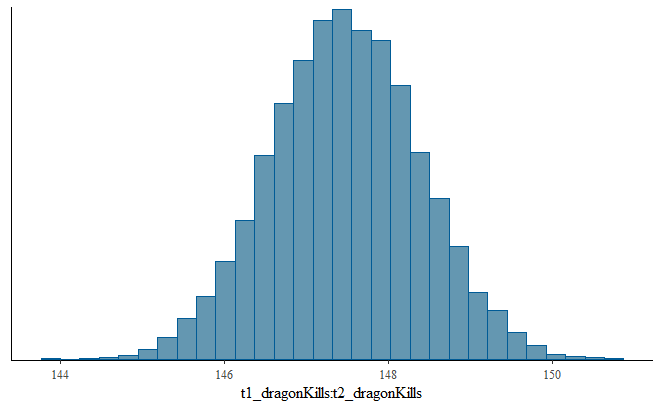

```r
# Extract the posterior samples
posterior_samples <- as.matrix(int)
posterior_samples2 <- as.matrix(int2)

# Plot the posterior distribution of the interaction term
mcmc_hist(posterior_samples, pars = c("t1_dragonKills:t2_dragonKills"))
```

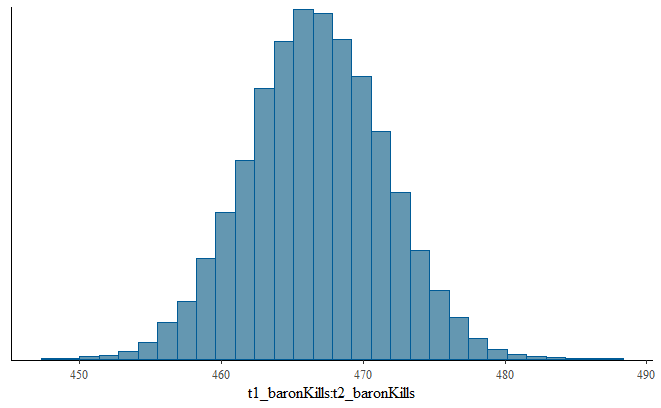

```r
mcmc_hist(posterior_samples2, pars = c("t1_baronKills:t2_baronKills"))
```

The predictors don’t look skewed either, looks good.

We can canclude that there may be a potential interaction between dragon kills and baron kills for each team

We can utilize this info later on upon building a better model

## Main Model

Let’s assess how much getting a jump start in the game does for determining the length of the game

```r
main <- stan_glm(gameDuration ~ winner + firstBlood + firstTower + firstDragon + firstBaron,
  data = lol_data, family = gaussian,
  prior_intercept = normal(1800, 150, autoscale = TRUE),
  prior = normal(0, 2.5, autoscale = TRUE),
  prior_aux = exponential(1, autoscale = TRUE),
  chains = 4, iter = 5000*2, seed = 84735)
```

```r
prior_summary(main)
```

```
Priors for model 'main'
------
Intercept (after predictors centered)
  Specified prior:
    ~ normal(location = 1800, scale = 150)
  Adjusted prior:
    ~ normal(location = 1800, scale = 64093)

Coefficients
  Specified prior:
    ~ normal(location = [0,0,0,...], scale = [2.5,2.5,2.5,...])
  Adjusted prior:
    ~ normal(location = [0,0,0,...], scale = [2136.54,2137.02,2137.26,...])

Auxiliary (sigma)
  Specified prior:
    ~ exponential(rate = 1)
  Adjusted prior:
    ~ exponential(rate = 0.0023)
------
See help('prior_summary.stanreg') for more details
```

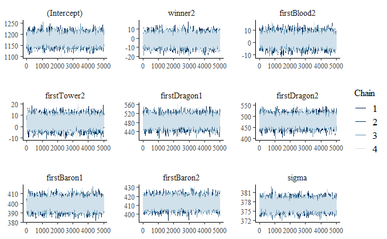

```r
mcmc_trace(main, size = .1)
```

Chains look normal

```r
rhat(main)
```

```
 (Intercept)      winner2  firstBlood2  firstTower2 firstDragon1
   1.0001252    1.0000866    0.9999479    0.9999554    1.0000860
firstDragon2  firstBaron1  firstBaron2        sigma
   1.0001157    1.0000559    0.9999221    1.0000304
```

```r
neff_ratio(main)
```

```
 (Intercept)      winner2  firstBlood2  firstTower2 firstDragon1
     0.56465      1.06070      1.40485      1.23750      0.54275
firstDragon2  firstBaron1  firstBaron2        sigma
     0.54175      1.05630      1.05235      1.12255
```

Rhat looks good, some of the neff ratio values are still high but acceptable for now

```r
tidy(main, effects = c("fixed", "aux"),
     conf.int = TRUE, conf.level = 0.95)
```

| term | estimate | std.error | conf.low | conf.high |
| --- | --- | --- | --- | --- |
| (Intercept) | 1175.597716 | 18.268605 | 1140.505428 | 1211.325195 |
| winner2 | -1.916742 | 4.512413 | -10.916791 | 7.032850 |
| firstBlood2 | 2.037023 | 3.636805 | -5.039785 | 9.151422 |
| firstTower2 | 4.049068 | 3.946881 | -3.819730 | 11.737633 |
| firstDragon1 | 485.586274 | 18.626207 | 449.609860 | 521.251610 |
| firstDragon2 | 477.985237 | 18.645316 | 441.912668 | 513.881729 |
| firstBaron1 | 399.276877 | 4.572101 | 390.362990 | 408.279724 |
| firstBaron2 | 412.844307 | 4.593653 | 403.939362 | 421.765679 |
| sigma | 377.006879 | 1.252637 | 374.581057 | 379.490092 |
| mean_PPD | 1929.808429 | 2.489931 | 1924.893958 | 1934.693193 |

From the tidy output, it looks like winner, firstBlood, and firstTower lose their significance when adding other predictors since their 95% CI range includes 0. We’ll use this info later for refining our model

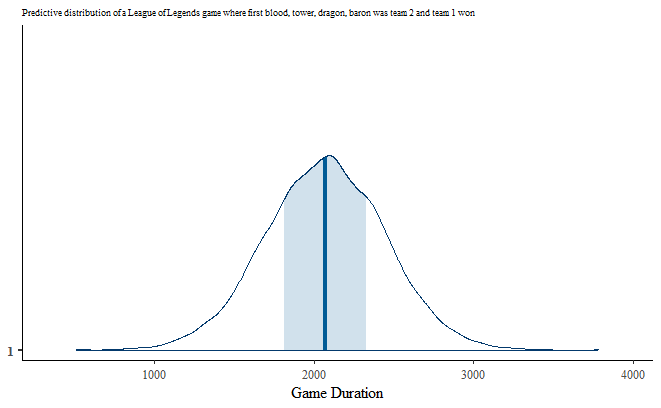

```r
newdata <- data.frame(winner = factor(1, levels = levels(lol_data$winner)),
                      firstBlood = factor(2, levels = levels(lol_data$firstBlood)),
                      firstTower = factor(2, levels = levels(lol_data$firstTower)),
                      firstDragon = factor(2, levels = levels(lol_data$firstDragon)),
                      firstBaron = factor(2, levels = levels(lol_data$firstBaron)))

main_predict <- posterior_predict(
  main,
  newdata = newdata)
mcmc_areas(main_predict) +  xlab("Game Duration") +
  ggtitle('Predictive distribution of a League of Legends game where first blood, tower, dragon, baron was team 2 and team 1 won') +
  theme(plot.title = element_text(size = 7))
```

Here’s an example output of where a game duration may lie if team 1 wins despite being behind from the start. The game is a little later than normal, but to be expected as the team would need time to make the comeback in the first place. However, I believe this is undershooting the true time we could expect from this scenario. We’ll verify if this is true after refining our model

## More Predictors

We can add some numerical variables to see how much adding the amount of each objective a team has taken to see how it affects the game duration

```r
ext_main <- stan_glm(gameDuration ~ winner + firstBlood + firstTower + firstDragon + firstBaron + t1_towerKills + t1_inhibitorKills + t1_baronKills + t1_dragonKills + t2_towerKills + t2_inhibitorKills + t2_baronKills + t2_dragonKills,
  data = lol_data, family = gaussian,
  prior_intercept = normal(1800, 150, autoscale = TRUE),
  prior = normal(0, 2.5, autoscale = TRUE),
  prior_aux = exponential(1, autoscale = TRUE),
  chains = 4, iter = 5000*2, seed = 84735)
```

```r
prior_summary(ext_main)
```

```
Priors for model 'ext_main'
------
Intercept (after predictors centered)
  Specified prior:
    ~ normal(location = 1800, scale = 150)
  Adjusted prior:
    ~ normal(location = 1800, scale = 64093)

Coefficients
  Specified prior:
    ~ normal(location = [0,0,0,...], scale = [2.5,2.5,2.5,...])
  Adjusted prior:
    ~ normal(location = [0,0,0,...], scale = [2136.54,2137.02,2137.26,...])

Auxiliary (sigma)
  Specified prior:
    ~ exponential(rate = 1)
  Adjusted prior:
    ~ exponential(rate = 0.0023)
------
See help('prior_summary.stanreg') for more details
```

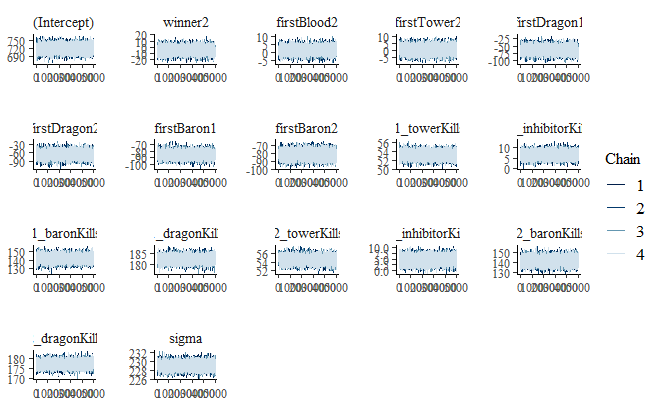

```r
mcmc_trace(ext_main, size = .1)
```

Traces look good

```r
rhat(ext_main)
```

```
      (Intercept)           winner2       firstBlood2       firstTower2
        0.9999612         0.9999395         0.9999895         0.9998515
     firstDragon1      firstDragon2       firstBaron1       firstBaron2
        1.0000056         1.0000145         1.0001244         1.0001247
    t1_towerKills t1_inhibitorKills     t1_baronKills    t1_dragonKills
        0.9999698         1.0000633         1.0001761         0.9998990
    t2_towerKills t2_inhibitorKills     t2_baronKills    t2_dragonKills
        0.9998515         0.9999585         1.0003134         0.9999253
            sigma
        0.9998820
```

```r
neff_ratio(ext_main)
```

```
      (Intercept)           winner2       firstBlood2       firstTower2
          0.58290           0.79920           2.05680           1.44595
     firstDragon1      firstDragon2       firstBaron1       firstBaron2
          0.48310           0.48375           0.66920           0.65460
    t1_towerKills t1_inhibitorKills     t1_baronKills    t1_dragonKills
          0.71785           1.02960           0.65910           0.94240
    t2_towerKills t2_inhibitorKills     t2_baronKills    t2_dragonKills
          0.74235           1.01930           0.65770           0.91395
            sigma
          1.16840
```

Rhat looks good, some neff ratios (i.e. firstBlood, firstTower) are now too high to keep and will need to be handled later

```r
tidy(ext_main, effects = c("fixed", "aux"),
     conf.int = TRUE, conf.level = 0.95)
```

| term | estimate | std.error | conf.low | conf.high |
| --- | --- | --- | --- | --- |
| (Intercept) | 718.8876102 | 12.5344301 | 694.387213 | 742.975191 |
| winner2 | -4.7502507 | 5.2610451 | -15.102444 | 5.536997 |
| firstBlood2 | 1.3696343 | 2.2181358 | -3.036018 | 5.682566 |
| firstTower2 | 0.5225051 | 2.6136817 | -4.613316 | 5.589730 |
| firstDragon1 | -62.4861168 | 11.6525919 | -84.845021 | -39.800894 |
| firstDragon2 | -65.2712585 | 11.6968991 | -87.518969 | -42.548125 |
| firstBaron1 | -85.3784456 | 4.9926841 | -95.093140 | -75.449487 |
| firstBaron2 | -81.5191696 | 4.7989714 | -90.953878 | -72.017096 |
| t1_towerKills | 53.2244136 | 0.7876256 | 51.720278 | 54.721935 |
| t1_inhibitorKills | 6.6477314 | 1.5221904 | 3.690422 | 9.665713 |

[output cut: 8 more lines]

Here, the predictors winner, firstBlood, and firstTower are not significant due to their 95% CI including 0

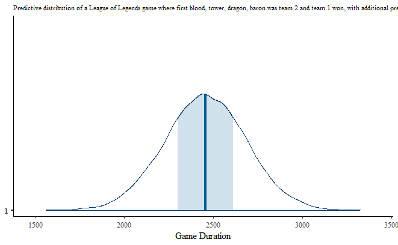

```r
# dataframe with the specified values
newdata_ext <- data.frame(
  winner = factor(1, levels = levels(lol_data$winner)),
  firstBlood = factor(2, levels = levels(lol_data$firstBlood)),
  firstTower = factor(2, levels = levels(lol_data$firstTower)),
  firstDragon = factor(2, levels = levels(lol_data$firstDragon)),
  firstBaron = factor(2, levels = levels(lol_data$firstBaron)),
  t1_towerKills = 7,
  t1_inhibitorKills = 2,
  t1_baronKills = 2,
  t1_dragonKills = 2,
  t2_towerKills = 3,
  t2_inhibitorKills = 2,
  t2_baronKills = 1,
  t2_dragonKills = 3
)

ext_main_predict <- posterior_predict(ext_main, newdata = newdata_ext)

mcmc_areas(ext_main_predict) +
  xlab("Game Duration") +
  ggtitle('Predictive distribution of a League of Legends game where first blood, tower, dragon, baron was team 2 and team 1 won, with additional predictors') +
  theme(plot.title = element_text(size = 8))
```

After adding a few more variables into play we can see the game gets longer (and expectedly so). Team 1 comes from behind but ends up getting 2 barons and 7 towers making us believe this game will have to go on for a while for the comeback to truly be complete